# Airbnb & Zillow Data Challenge

Manoj Kumar Eega

# New York Property Analysis

## **Introduction**

A real estate company plans to purchase properties in New York City and use Airbnb as the medium to lease out their investment property. The main objective of the real estate company is to find out the zip codes in New York City that would generate the most profit on short term rentals. We are looking to find out the best zip codes to invest within New York City.

Two data sets, Airbnb and Zillow are available. Zillow provides data on estimated value of two-bedroom properties. Airbnb dataset provides data on how much properties in certain neighborhoods rent out for in New York City.

## **Assumptions**

> 1. An occupancy rate of 75%
> 2. No additional maintenance costs
> 3. Time value of money discount rate is 0%
> 4. Rent of a ‘m’ bedroom property is m/n times of that of a ‘n’ bedroom property
> 5. Investor pays for the property upfront in cash
> 6. Indirect discounts due to bulk bookings and special promotional discounts were not taken into consideration

## **Data Preparation**

Prior to the analysis , it is essential to properly load, examine and clean the data

**============> =============> =============> =============> ==============> =============> ============>**

### **Packages Required**

To reproduce the results of this project you will need to load the following packages

```r
library(tidyverse) # Collection of R packages designed for data science.
library(knitr) #A general-purpose tool for dynamic report generation in R
library(ggplot2) # Aesthetic depiction library
library(kableExtra) # Aesthetic depiction of tables in Rmarkdown
library(scales) # To work with axis in charts
```

### **Loading the data**

The data for this project originated from the following source.

```r
listings <- read.csv("listings.csv") #Airbnb listings
zillowdata <- read.csv("Zip_Zhvi_2bedroom.csv") # Median Price of twobedroom properties
NY_zip  <- read.csv("New York zipcodes.csv") #List of all the zipcodes in New York city
```

#### Listings Data Description

> Information on the listings including - location, number of bedrooms, room types (entire home/private home/shared home)

| Field | Description |
| --- | --- |
| id | Identifier used by AirBnB for the listing |
| listing_url | URL used by AirBnB for their listing |
| scrape_id | Identifier used internally by AirBnB to identify the date of the data |
| last_scraped | Identifier used internally by AirBnB to identify when the data was last pulled. |
| name | Header created by host to entice potential occupants to stay at their property |
| summary | Description provided by the host of their property |
| space | Description provided by host describing the space (bedrooms, bathrooms, sqft, etc) of their property |
| description | Detailed information about the property, neighborhood, amenities, location, and anything else the host feels would be beneficial to share |
| experiences_offered | Information about what experiences are offered; eg. Bikes, surfing, canoes, etc |
| neighborhood_overview | Additional detail about the neighborhood including sites to see, restaurants, noise, landmarks around, etc. |
| notes | Any other additional notes the host would like to disclose, which was not provided in the other description information. |
| transit | Host can provide the kind of transportation available nearby including bus, trains, airport, etc.. |
| access | Description on how to enter the home, what area of the home is available for use, and what you are able items you are able to use during your stay. |
| interaction | The availability of the host; could be in person, phone, email, text, etc. The host provides guidelines of what the occupant can expect for communication and if they expect to meet. |
| house_rules | The host provides rules of the home that they expect the occupant to adhere to. Examples include clean up, laundry, dishes, etc. |
| thumbnail_url | URL specific to AirBnB where the posted pictures are stored. |
| medium_url | URL specific to AirBnB where the posted pictures are stored. |
| picture_url | URL specific to AirBnB where the posted pictures are stored. |
| xl_picture_url | URL specific to AirBnB where the posted pictures are stored. |
| host_id | Identifier assigned to a particular host. A host can have multiple properties listed and would have the same unique identifier. |
| host_url | URL assigned to the host for their listing. |
| host_name | Name of the host. |
| host_since | Date of when the host first initiated their account with AirBnB. |
| host_location | City, State, and Country of where the host is located. |
| host_about | Information provided by host to potential occupant. |
| host_response_time | Time a potential occupant can expect to receive a response after inquiring about the property. |
| host_response_rate | Percentage of historical responses |
| host_acceptance_rate | Percentage of historical acceptances from potential occupants. This information is currently unavailable. |
| host_is_superhost | Superhosts are experienced hosts who provide a shining example for other hosts, and extraordinary experiences for their guests. |
| host_thumbnail_url | URL assigned to host where the pictures are posted |

[output cut: 65 more lines]

#### Zillow Data Description

> Cost data to determine the average property price for 2 bedrooms

| Field | Description |
| --- | --- |
| RegionID | Zillow assigned number only, assigned consecutively when the regions are defined. |
| RegionName | Zip code of where the property is located. |
| City | City of where the property is located. |
| State | State of where the property is located. |
| Metro | General name of the surrounding area where the property is located. |
| CountyName | Political and administrative division of a state, referred to as a particular part of the state. |
| SizeRank | Population of the area; the lower the number the greater the population. |
| 1996-04 – XXXX-XX ((XXXX-XX indicates the latest date available at the time the data is pulled) | Indicates the historical median price within that area. |

#### NY_zip Description

> Official list of all the zipcodes available in New York city

#### Structure of Listings Data

It is a dataframe with 48895 Observations and 106 Variables

```
## 'data.frame':    48895 obs. of  106 variables:
##  $ id                                          : int  2539 2595 3647 3831 5022 5099 5121 5178 5203 5238 ...
##  $ listing_url                                 : Factor w/ 48895 levels "https://www.airbnb.com/rooms/10000070",..: 21404 21961 39206 39474 41416 41514 41543 41592 41625 41660 ...
##  $ scrape_id                                   : num  2.02e+13 2.02e+13 2.02e+13 2.02e+13 2.02e+13 ...
##  $ last_scraped                                : Factor w/ 2 levels "2019-07-08","2019-07-09": 2 2 1 2 1 1 2 1 1 1 ...
##  $ name                                        : Factor w/ 47906 levels "","'Fan'tastic",..: 12661 38172 45171 15702 19366 25001 8337 25048 15597 17682 ...
##  $ summary                                     : Factor w/ 43807 levels "","----This a listing for our photo studio.  The space does not offer overnight stays---- With an abundance of Sou"| __truncated__,..: 29689 13422 1 40376 1 22465 1 27616 26184 19463 ...
##  $ space                                       : Factor w/ 32171 levels "","---------------------------------------------------------------------------------------------------------------"| __truncated__,..: 18395 201 30500 8115 12328 9504 8648 31798 18480 16185 ...
##  $ description                                 : Factor w/ 46250 levels "","----------------------- THE APARTMENT ----------------------- **SUMMER ALERT:  Apartment is FULLY AIRCONDITIONE"| __truncated__,..: 31270 14116 44645 42618 21635 23689 16093 29099 27589 20535 ...
##  $ experiences_offered                         : Factor w/ 1 level "none": 1 1 1 1 1 1 1 1 1 1 ...
##  $ neighborhood_overview                       : Factor w/ 26905 levels "","''Stuyvesant hight'' is a trendy and safe neighborhood, their is plenty of coffee shops, restaurants and stores"| __truncated__,..: 4516 3890 1 10157 1 12131 1 21046 13722 8179 ...
##  $ notes                                       : Factor w/ 17018 levels "","'Minibar' is the name of the best app for beer, wine, and liquor delivery. 'Seamless' is the main food delivery"| __truncated__,..: 5563 1 1 1 1 10205 1 10272 2164 14126 ...
##  $ transit                                     : Factor w/ 28041 levels "","'very very close to L express to manhattan! JMZ on broadway one block away>  sometimes you hear the train runni"| __truncated__,..: 24517 4488 1 4789 1 8116 1 1 20931 7719 ...
##  $ access                                      : Factor w/ 23435 levels "","---------------------------------------------------------------------------------------------------------------"| __truncated__,..: 1 8448 1 22621 1 10294 1 2632 8780 8179 ...
##  $ interaction                                 : Factor w/ 24970 levels "","---------------------------------------------------------------------------------------------- ----------------"| __truncated__,..: 1 6204 1 19711 1 10508 1 1 16482 19266 ...
```

[output cut: 86 more lines]

#### Structure of Zillow Data

It is a dataframe with 8946 obs. of 262 variables

```
## 'data.frame':    8946 obs. of  262 variables:
##  $ RegionID  : int  61639 84654 61637 84616 93144 84640 97564 91982 71831 84646 ...
##  $ RegionName: int  10025 60657 10023 60614 79936 60640 94109 77494 32162 60647 ...
##  $ City      : Factor w/ 4684 levels "Aberdeen","Abilene",..: 2702 649 2702 649 1119 649 3479 672 3912 649 ...
##  $ State     : Factor w/ 48 levels "AK","AL","AR",..: 34 15 34 15 42 15 5 42 10 15 ...
##  $ Metro     : Factor w/ 467 levels "","Aberdeen",..: 292 76 292 76 125 76 368 188 415 76 ...
##  $ CountyName: Factor w/ 722 levels "Ada","Adams",..: 460 158 460 158 212 158 574 231 634 158 ...
##  $ SizeRank  : int  1 2 3 4 5 6 7 8 9 10 ...
##  $ X1996.04  : int  NA 167700 NA 195800 59100 123300 336800 117300 72600 129600 ...
##  $ X1996.05  : int  NA 166400 NA 193500 60500 122600 337400 117900 74800 129800 ...
##  $ X1996.06  : int  NA 166700 NA 192600 60900 122000 337700 118800 77300 129900 ...
##  $ X1996.07  : int  NA 167200 NA 192300 60800 121500 338200 121100 80000 130600 ...
##  $ X1996.08  : int  NA 166900 NA 192600 60300 120900 339700 123200 81700 131100 ...
##  $ X1996.09  : int  NA 166900 NA 193600 60400 120600 340400 124600 82600 131200 ...
##  $ X1996.10  : int  NA 168000 NA 195500 61200 120900 339700 125800 83500 131000 ...
```

[output cut: 86 more lines]

### **Filter New York Entries**

#### New York Listings data

Since our analysis confines to the properties in the New York city, we can filter the corresponding entries in both “listings” and “zillowdata”

```r
sum(duplicated(listings)) # Checking for duplicated entries
```

```
## [1] 0
```

```r
sum(is.na(listings$zipcode)) # Checking for missing values in the zipcode column
```

```
## [1] 0
```

```r
sum(is.na(listings$square_feet))/nrow(listings) # checking missing values in sq.ft column
```

```
## [1] 0.9916556
```

But looking at the unique values in the listings data would reveal that some missing values are disguised as blank spaces

```r
unique(listings$zipcode) # Blank Spaces Spotted
```

```
##   [1] 11218        10018        10027        11238        10029
##   [6] 10016        11216        10019        10025        10002
##  [11] 10036        11215        10014        11211        11205
##  [16] 10011        11217        10034        10003        10031
##  [21] 11222                     11237        11226        10009
##  [26] 10024        11225        11101        11221        11206
##  [31] 10010        11249        10001        10162        10035
##  [36] 10032        10075        11377        11201        11233
##  [41] 11231        10023        10128        10040        11234
##  [46] 11367        10028        11104        10065        10301
##  [51] 10452        10006        10039        11385        10021
##  [56] 11434        11379        10026        11105        10044
##  [61] 10022        10013        11103        10473        10475
##  [66] 11213        10468        11102        10038        10033
##  [71] 11427        11693        10012        11375        10470
```

[output cut: 26 more lines]

```r
sum(listings$zipcode == "")/nrow(listings)*100 #Very small percentage of missing values(1%)
```

```
## [1] 1.057368
```

```r
#We can ignore the entries with missing zipcodes ony after making sure that the percentage of entries with missing zipcodes is minimal in each and every neighborhood , since our final analysis includes comparision of local averages.

df = as.data.frame(table(listings[listings$zipcode == "", "neighbourhood"]))
df <- df[df$Freq != 0, ]
names(df) <- c("neighbourhood","Frequency")
class(df)
```

```
## [1] "data.frame"
```

```r
#newdf <- df %>% mutate(missing_percent = df$Frequency/)


df <- df[order(-df$Frequency), ] #List of no. of entries with missing zipcodes w.r.t neighbourhood


missing_zipcode_entrylist = as.data.frame(table(listings[listings$zipcode == "", "neighbourhood"]))
missing_zipcode_entrylist <- missing_zipcode_entrylist[missing_zipcode_entrylist$Freq != 0, ]
names(missing_zipcode_entrylist) <- c("neighbourhood","Frequency")
class(missing_zipcode_entrylist)
```

```
## [1] "data.frame"
```

```r
missing_zipcode_entrylist <- missing_zipcode_entrylist[order(-missing_zipcode_entrylist$Frequency), ] #List of no. of entries with missing zipcodes w.r.t neighbourhood

#Checking the local missing value percentage in top 3 in the list


df1 <- missing_zipcode_entrylist[missing_zipcode_entrylist$neighbourhood == "Brooklyn" , ]$Frequency
df1 # no. of entries with missing zipcodes in Brooklyn
```

```
## [1] 113
```

```r
Brooklyn_percent = df1/nrow(listings[listings$neighbourhood == "Brooklyn" , ])*100 # percent of entries with missing zipcodes in Brooklyn

df2 <- df[df$neighbourhood == "Manhattan" , ]$Frequency
df2 # no. of entries with missing zipcodes in Manhattan
```

```
## [1] 105
```

```r
Manhattan_percent = df2/nrow(listings[listings$neighbourhood == "Manhattan" , ])*100 # percent of entries with missing zipcodes in Manhattan

df3 <- df[df$neighbourhood == "Queens" , ]$Frequency
df3  #no. of entries with missing zipcodes in Queens
```

```
## [1] 29
```

```r
Queens_percent = df3/nrow(listings[listings$neighbourhood == "Queens" , ])*100 # percent of entries with missing zipcodes in Queens

Brooklyn_percent
```

```
## [1] 1.046878
```

```r
Manhattan_percent
```

```
## [1] 1.038884
```

```r
Queens_percent
```

```
## [1] 1.029464
```

```r
#df1
#str(df)
#sum(df$Var1  %like% "Man%")
#df[Var1 %like% "^Man"]
#df[Var1  ("Manhattan") , ]
#df
#res = hist(listings[listings$zipcode == "" , "city"])
```

```r
NY_zip_char <- NY_zip %>% mutate(X10001  = as.character(X10001)) # Matching the class of variables containing zipcode in both "listings" and "NY_zip"

listings <- listings %>% mutate(zipcode = as.character(zipcode))
listingsNY <- listings[listings$zipcode %in% NY_zip_char[ , 1], ] # Filtering out data corresponding to zipcodes in New YOrk city
unique(listingsNY$zipcode)
```

```
##   [1] "11218" "10018" "10027" "11238" "10029" "10016" "11216" "10019"
##   [9] "10025" "10002" "10036" "11215" "10014" "11211" "11205" "10011"
##  [17] "11217" "10034" "10003" "10031" "11222" "11237" "11226" "10009"
##  [25] "10024" "11225" "11101" "11221" "11206" "10010" "11249" "10001"
##  [33] "10162" "10035" "10032" "11377" "11201" "11233" "11231" "10023"
##  [41] "10128" "10040" "11234" "11367" "10028" "11104" "10301" "10452"
##  [49] "10006" "10039" "11385" "10021" "11434" "11379" "10026" "11105"
##  [57] "10044" "10022" "10013" "11103" "10473" "10475" "11213" "10468"
##  [65] "11102" "10038" "10033" "11427" "11693" "10012" "11375" "10470"
##  [73] "10030" "10453" "11223" "10469" "11208" "11207" "10451" "11235"
##  [81] "10314" "11209" "11204" "10305" "11232" "10017" "11373" "11224"
##  [89] "11372" "11412" "10004" "11203" "11374" "10466" "11106" "10304"
##  [97] "11220" "11230" "11210" "10303" "11229" "10463" "11435" "11416"
## [105] "10005" "10454" "10455" "11236" "10280" "10037" "11355" "11692"
## [113] "11411" "10282" "10307" "11219" "10467" "11358" "11361" "10069"
## [121] "11415" "11356" "11214" "11432" "10464" "11370" "10302" "11418"
## [129] "11433" "11429" "11422" "11378" "11421" "10312" "10460" "10471"
## [137] "10462" "10459" "11417" "10007" "11360" "11109" "11357" "10458"
## [145] "11369" "11212" "11691" "11354" "11368" "10306" "10456" "11413"
## [153] "11365" "11436" "11414" "11694" "11366" "10457" "10461" "10310"
## [161] "11420" "10308" "11419" "10474" "10465" "10472" "11428" "11426"
## [169] "11423" "11228" "11364" "11363" "10281" "11362" "10174" "10270"
## [177] "10309" "10020"
```

> **listingsNY** contains listings pertaining to New YOrk city

#### New York Median Price data

```r
sum(duplicated(zillowdata)) # Checking for duplicate entries
```

```
## [1] 0
```

```r
sum(is.na(zillowdata$RegionName)) # Checking for missing values in Region Name column which contains zipcodes
```

```
## [1] 0
```

```r
twobedNY <- zillowdata[zillowdata$RegionName %in% NY_zip[ , 1] ,  ] #Filtering out available median price data for zipcodes in New York City
```

> **twobedNY** contains history of Median Price data of properties in New YOrk city

### **Critical parameter identification for data quality check**

#### Preliminary Analysis

##### **Filtering critical parameters by Analyzing factors affecting Revenue and Investment**

| Revenue_factors | Assumptions | Remarks |
| --- | --- | --- |
| Rent |  | “zipcode”, “Price”, “monthly_price”,“weekly_price” to be checked |
| Bedrooms | Rent of a ‘m’ bedroom property is m/n times of that of a ‘n’ bedroom property | “bedrooms” |
| Occupancy | Occupancy assumed to be 75% | So we can filter out measures relating to reviews,host qualities, bookability, web urls and neighborhood , latitude and longitude |
| Additional Maintenance costs |  |  |
| Indirect discounts due to bulk bookings | Assumed to be zero |  |
| Special Promotional discounts | Assumed to be zero |  |

| Investment_factors | Assumptions | Remarks |
| --- | --- | --- |
| Median Price of the property | Latest available Median price data taken as price at the time of investment | “RegionName” and “x2017.06” are to be checked |

[output not shown]

#### Data Quality Insights of critical parameters

##### **Data Quality check for Airbnb listings data**

After the above preliminary analysis

- *Critical parameters in ListingsNY data - “zipcode”, “Price”, “monthly_price”,“weekly_price” , “bedrooms”*

```r
#checking the class of all the critical variables
class(listingsNY$zipcode)
```

```
## [1] "character"
```

```r
class(listingsNY$price)
```

```
## [1] "factor"
```

```r
class(listingsNY$monthly_price)
```

```
## [1] "factor"
```

```r
class(listingsNY$weekly_price)
```

```
## [1] "factor"
```

```r
class(listingsNY$bedrooms)
```

```
## [1] "integer"
```

- *Changing the variable types from factor to numeric as well as removing special characters*

```r
# changing the variables with rent information  from factor to numeric

listingsNY$zipcode <- as.character(listingsNY$zipcode)

listingsNY$monthly_price <-  as.character(listingsNY$monthly_price)
listingsNY$monthly_price <-  str_replace_all(listingsNY$monthly_price ,"\\$" , "")
listingsNY$monthly_price <-  str_replace_all(listingsNY$monthly_price ,"\\," , "")
listingsNY$monthly_price <- as.numeric(listingsNY$monthly_price)



listingsNY$price <-  as.character(listingsNY$price)
listingsNY$price <-  str_replace_all(listingsNY$price ,"\\$" , "")
listingsNY$price <-  str_replace_all(listingsNY$price ,"\\," , "")
listingsNY$price <- as.numeric(listingsNY$price)


listingsNY$weekly_price <-  as.character(listingsNY$weekly_price)
listingsNY$weekly_price <-  str_replace_all(listingsNY$weekly_price ,"\\$" , "")
listingsNY$weekly_price <-  str_replace_all(listingsNY$weekly_price ,"\\," , "")
listingsNY$weekly_price <- as.numeric(listingsNY$weekly_price)
```

- *Checking percentage of missing values in price related variables*

```r
sum(is.na(listingsNY$price))/nrow(listingsNY)*100
```

```
## [1] 0
```

```r
sum(is.na(listingsNY$monthly_price))/nrow(listingsNY)*100
```

```
## [1] 89.29476
```

```r
sum(is.na(listingsNY$weekly_price))/nrow(listingsNY)*100
```

```
## [1] 87.63782
```

```r
sum(is.na(listingsNY$bedrooms))/nrow(listingsNY)*100
```

```
## [1] 0.04184188
```

> Since they have high percentage (~89%) of missing values , **“monthly_price” and “weekly_price” columns cannot be used for the analysis** **only “price” is selected as critical parameter**

> Remove the rows with no values for bedrooms(.04%, so negligible), since equivalent twobed price is calculated by the assumption (Assumption no.4) of direct proportionality of rent with no.of bedrooms

```r
listingsNY <- listingsNY[complete.cases(listingsNY$bedrooms), ]
```

```r
class(listingsNY$zipcode)
```

```
## [1] "character"
```

```r
unique(listingsNY$zipcode) #Checking for abnormal values
```

```
##   [1] "11218" "10018" "10027" "11238" "10016" "11216" "10019" "10025"
##   [9] "10002" "10036" "11215" "10014" "11205" "10011" "10029" "11217"
##  [17] "10034" "10003" "10031" "11222" "11237" "11226" "10009" "10024"
##  [25] "11225" "11101" "11221" "11206" "10010" "11211" "11249" "10001"
##  [33] "10162" "10035" "10032" "11377" "11201" "11233" "11231" "10023"
##  [41] "10128" "10040" "11234" "11367" "10028" "11104" "10301" "10452"
##  [49] "10006" "10039" "11385" "10021" "11434" "11379" "10026" "11105"
##  [57] "10044" "10022" "10013" "11103" "10473" "10475" "11213" "10468"
##  [65] "11102" "10038" "10033" "11427" "11693" "10012" "11375" "10470"
##  [73] "10030" "10453" "11223" "10469" "11208" "11207" "10451" "11235"
##  [81] "10314" "11209" "11204" "10305" "11232" "10017" "11373" "11224"
##  [89] "11372" "11412" "10004" "11203" "11374" "10466" "11106" "10304"
##  [97] "11220" "11230" "11210" "10303" "11229" "10463" "11435" "11416"
## [105] "10005" "10454" "10455" "11236" "10280" "10037" "11355" "11692"
## [113] "11411" "10282" "10307" "11219" "10467" "11358" "11361" "10069"
## [121] "11415" "11356" "11214" "11432" "10464" "11370" "10302" "11418"
## [129] "11433" "11429" "11422" "11378" "11421" "10312" "10460" "10471"
## [137] "10462" "10459" "11417" "10007" "11360" "11109" "11357" "10458"
## [145] "11369" "11212" "11691" "11354" "11368" "10306" "10456" "11413"
## [153] "11365" "11436" "11414" "11694" "11366" "10457" "10461" "10310"
## [161] "11420" "10308" "11419" "10474" "10465" "10472" "11428" "11426"
## [169] "11423" "11228" "11364" "11363" "10281" "11362" "10174" "10270"
## [177] "10309" "10020"
```

```r
# Counting the no.of abnormal values

sum(listingsNY$zipcode == "") #Missing values
```

```
## [1] 0
```

> Entries without zipcode information are not useful for our analysis, so I chose to delete the entries with missing zipcodes

```r
listingsNY <-  listingsNY[listingsNY$zipcode != "", ] # delete the entries with missing zipcodes
```

> Since equivalent twobed price is calculated by the assumption of direct proportionality of rent with no.of bedrooms , We cannot include listings with 0 bedrooms

```r
unique(listingsNY$bedrooms)
```

```
##  [1]  1  0  2  4  3  5  6  8  9  7 14 10 11
```

```r
sum(listingsNY$bedrooms == 0)
```

```
## [1] 4402
```

```r
#deleting entries w which have 0 bedrooms
listingsNY <- filter(listingsNY, bedrooms > 0)
```

> Parameters useful for further analysis are RegionName , x2017.06 (Latest Median Price data)

## **Transformed data**

> After filtering critical parameters from both the data , data is merged and new variables useful for the final analysis i.e., “revenue” (Estimated Annual Revenue), “break_even” (No. of years to break even the intial investment) and “ten_year_PI” (Profitability Index for 10 years) are created
- *Filtering critical parameters in listingsNY*

```r
criticallistingsNY <- listingsNY[ , c("zipcode","price","bedrooms")]
```

- *Filtering critical parameters from Median Price data (twobedNY)*

```r
criticaltwobedNY <- twobedNY[ , c("RegionName","X2017.06")]

names(criticaltwobedNY) <- c("zipcode" , "Latest_Median_Price") #Changing the column names to depict its summary
```

- *Joining the Listings data and the Median Price data*

```r
# Changing class of zipcode to match to that in criticallistings

criticaltwobedNY <-  criticaltwobedNY %>% mutate(zipcode  = as.character(zipcode))

criticallistingsNY <-  criticallistingsNY %>% mutate(zipcode  = as.character(zipcode))

# Joining the data through left_join
final <- criticallistingsNY %>% left_join(criticaltwobedNY, by = c("zipcode" = "zipcode"))

# Deleting entries which does not have a matching median price value
final <- final[is.na(final$Latest_Median_Price) == FALSE, ]
```

- *Addition of variable representing Revenue*
  - We assume that annual occupancy is 75%. So, to get the revenue generated by a 2-bed room property, we multiply ‘price’ by **0.75x365x(2/n)** to get annual revenue generated by that property, where n is the number of bedrooms present in that property. This value is stored in the column ‘revenue’.

### Creation of “revenue” variable representing Annual Revenue

```r
final$revenue = 0.75 * 365*final$price*(2/final$bedrooms) #Defining revenue variable
final <- final %>% group_by(zipcode) %>% mutate(zip_rev = mean(revenue))
```

| zipcode | price | bedrooms | Latest_Median_Price | revenue | zip_rev |
| --- | --- | --- | --- | --- | --- |
| 10025 | 79 | 1 | 1431000 | 43252.5 | 70440.79 |
| 10025 | 135 | 1 | 1431000 | 73912.5 | 70440.79 |
| 10036 | 85 | 1 | 1712900 | 46537.5 | 102563.29 |
| 11215 | 89 | 1 | 1070800 | 48727.5 | 57284.86 |
| 10025 | 85 | 1 | 1431000 | 46537.5 | 70440.79 |
| 10014 | 120 | 1 | 2491600 | 65700.0 | 117884.76 |

### Creation of variables representing “TIme to Break_even” and “Profitability Index of 10 years”

```r
rev_by_zipcode <-  final[ , c("zipcode","Latest_Median_Price","zip_rev")]

rev_by_zipcode <- rev_by_zipcode %>% as.data.frame() %>%  group_by(zipcode) %>% summarise_at(c("Latest_Median_Price" , "zip_rev"), mean, na.rm = TRUE)

rev_by_zipcode <- rev_by_zipcode %>%   mutate(break_even = Latest_Median_Price/zip_rev) %>% mutate(ten_year_PI = (10*zip_rev + Latest_Median_Price)/Latest_Median_Price)
knitr::kable(rev_by_zipcode) %>% kable_styling() # Creation of variables "break_even" and "ten_year_PI"
```

| zipcode | Latest_Median_Price | zip_rev | break_even | ten_year_PI |
| --- | --- | --- | --- | --- |
| 10003 | 2147000 | 94566.65 | 22.703564 | 1.440460 |
| 10011 | 2480400 | 109691.11 | 22.612590 | 1.442232 |
| 10013 | 3316500 | 111305.96 | 29.796249 | 1.335613 |
| 10014 | 2491600 | 117884.76 | 21.135896 | 1.473129 |
| 10021 | 1815600 | 84202.87 | 21.562210 | 1.463774 |
| 10022 | 2031600 | 107639.02 | 18.874197 | 1.529824 |
| 10023 | 2142300 | 120019.10 | 17.849659 | 1.560235 |
| 10025 | 1431000 | 70440.79 | 20.314933 | 1.492249 |
| 10028 | 2083900 | 80406.15 | 25.917170 | 1.385845 |
| 10036 | 1712900 | 102563.29 | 16.700908 | 1.598770 |
| 10128 | 1787100 | 76363.62 | 23.402506 | 1.427305 |
| 10303 | 327700 | 36008.65 | 9.100590 | 2.098830 |
| 10304 | 328300 | 38503.20 | 8.526565 | 2.172805 |
| 10305 | 425100 | 35829.10 | 11.864657 | 1.842839 |
| 10306 | 352900 | 37401.97 | 9.435332 | 2.059846 |
| 10308 | 409500 | 40902.81 | 10.011537 | 1.998848 |
| 10309 | 390500 | 89265.31 | 4.374600 | 3.285923 |
| 10312 | 355000 | 69053.44 | 5.140946 | 2.945167 |
| 10314 | 357300 | 31762.60 | 11.249078 | 1.888962 |
| 11201 | 1420700 | 79367.63 | 17.900244 | 1.558652 |
| 11215 | 1070800 | 57284.86 | 18.692547 | 1.534973 |
| 11217 | 1302300 | 67674.22 | 19.243664 | 1.519652 |
| 11231 | 1202900 | 62353.54 | 19.291608 | 1.518360 |
| 11234 | 476900 | 38997.21 | 12.229081 | 1.817723 |
| 11434 | 382300 | 37569.19 | 10.175892 | 1.982715 |

## **Visualization**

### Latest Median Price Chart

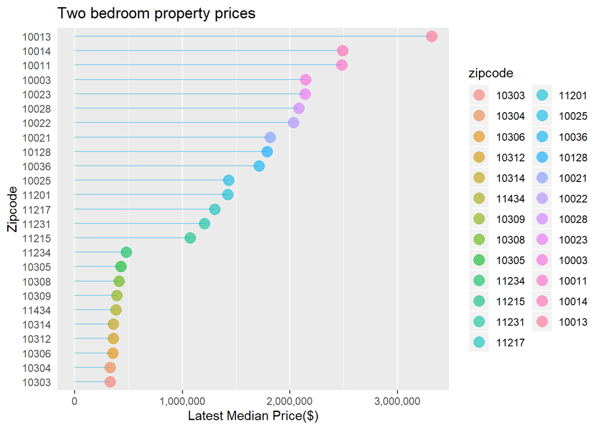

### Revenue through rent in different zipcodes

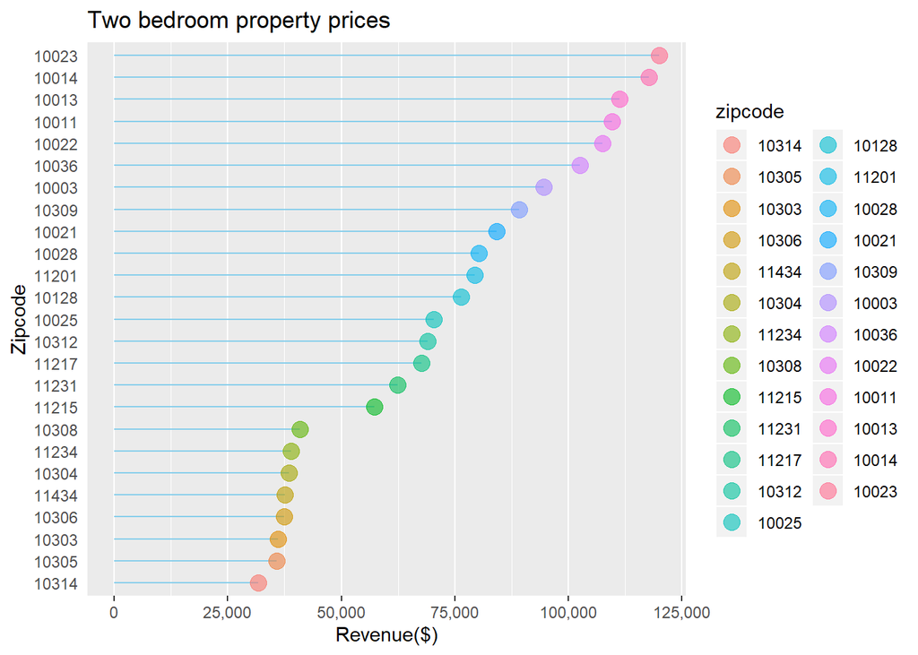

### Time to break even

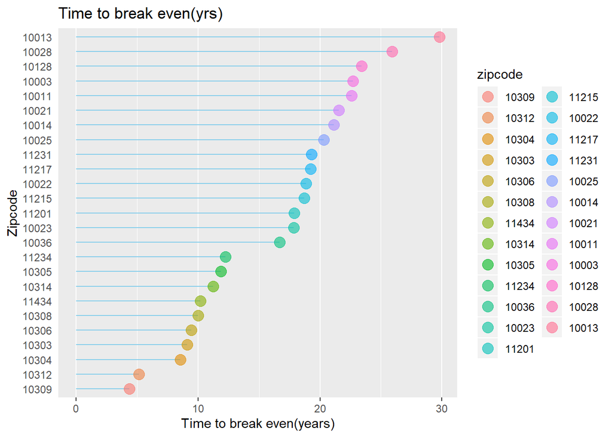

> Quickest break_even happens for zipcodes **10309 (Tottenville) , 10312(Eltingville) , 10304(Stapleton Heights)**

### Profitability Index for 10 years

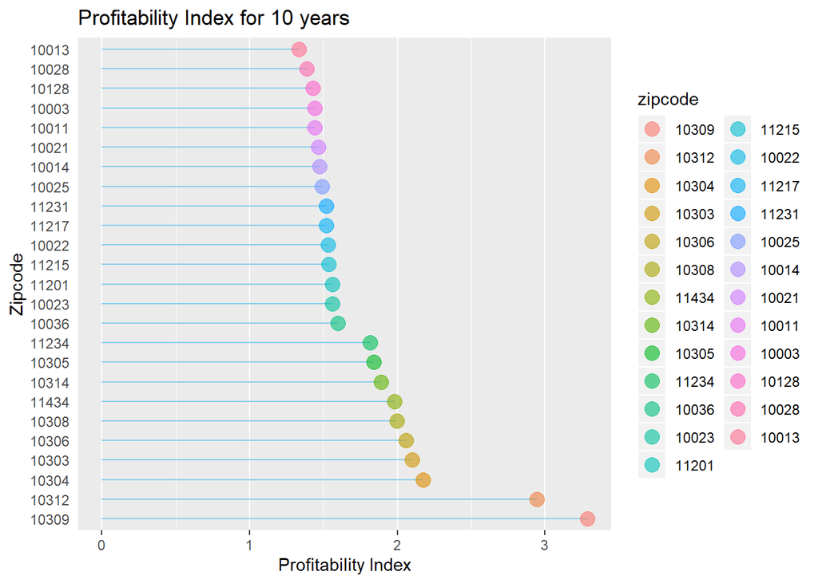

> Zipcodes **10309 , 10312 , 10304** have the highest PI after 10 years

## **Detailed Summary**

### Latest Median Price Chart

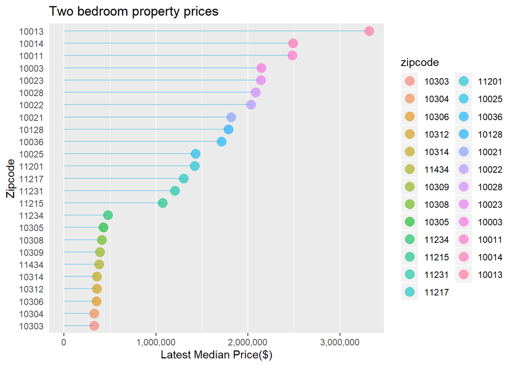

### Working with Airbnb listings dataset

Airbnb listings dataset has 48895 obs. of 106 variables Most of the variables present in this dataset are of no interest to us. After preliminary analysis , the variables of interest are ‘zipcode’, ‘price’ and ‘bedrooms’. Extract only those records whose zip codes match with the zip codes that we obtain from Zillow dataset. At the same time, filter out the records with zero number of bedrooms. Now, convert the character value in ‘price’ column into numeric column by removing ‘$’ and ‘,’ characters.

### 1. Estimation of profitable zipcodes through “Time to Break even”

$Time to break even = Investment/Annual Revenue$

Now, in each zip code, we calculate the number of years it takes for the property to break-even on the amount spent on purchasing it. This can simply be calculated by dividing cost of the property by annual revenue generated by the property. The column having these values is named ‘break_even’. This dataset is named ‘rev_by_zipcode’. The zip codes that requires the minimum amount of time to break even are the ones that are most profitable.

### 2. Estimation of profitable zipcodes through Profitability Index

$Profitability Index(PI) = (Present value of future cash flows)/(Intial Investment)$

Profitability Index represents the relationship between the costs and benefits of a proposed project. It is the ratio of present value of future cash flows and intial investment.Here , since time value of money discount rate is 0 . Assuming the properties sell at the same price after 10 years of being in the rental business.

- Present value of future cash flows of 10 years = 10 x Annual revenue + Latest Median Price of the property = 10 x zip_rev + Latest_Median_Price
- Intial Investment = Latest_Median_Price

### Revenue through rent in different zipcodes

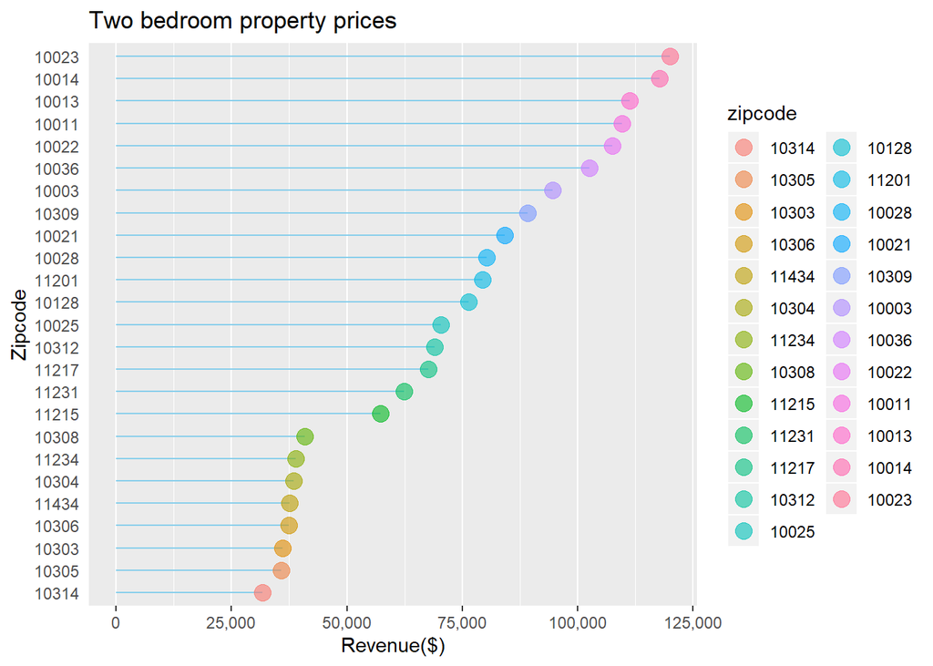

### Time to break even

[figure not shown]

> Quickest break_even point happens for zipcodes **10309 (Tottenville) , 10312(Eltingville) , 10304(Stapleton Heights)** in that order

### Profitability Index for 10 years

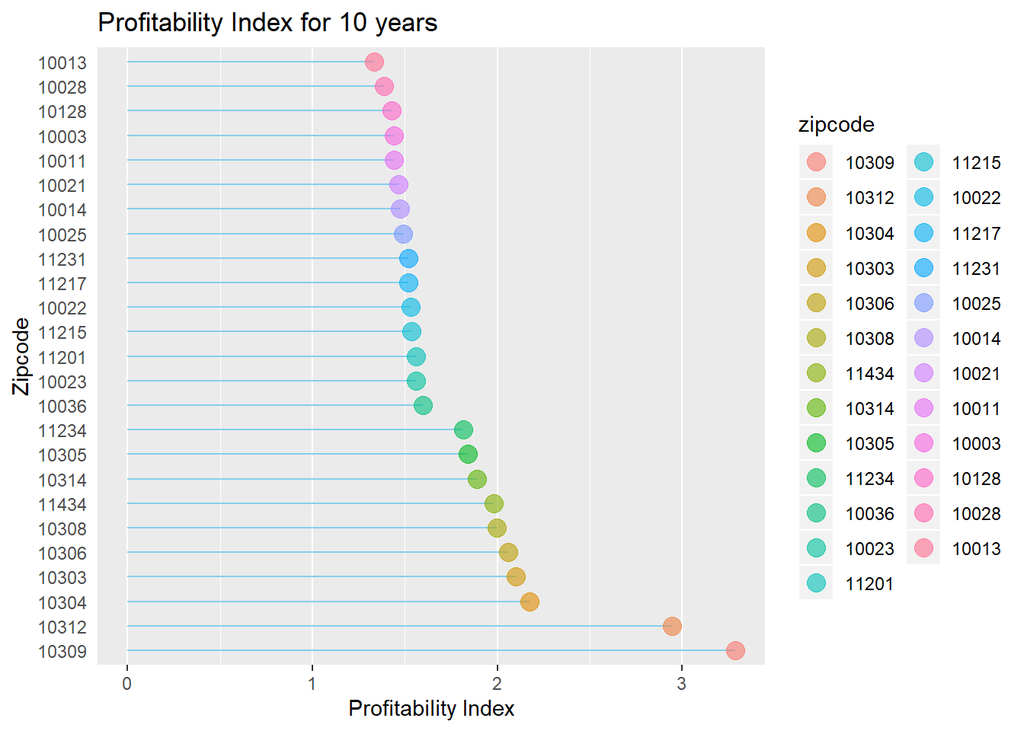

> Zipcodes **10309 (Tottenville) , 10312(Eltingville) , 10304(Stapleton Heights)** have the highest PI after 10 years in that order

### Additional scope

Since it is a 4 hour data challenge , some ideas which when implemented would help inform a better decision to the company. I list some below.

1. Since last few year price data is available to us, we can do time series analysis to better predict the current median price and use this for profitability analysis
2. R shiny can be used to build interactive dashboards , drop downs and slider bars for data filtering
3. Since median price data is available only for 25 zipcodes of New York city, more data can be procured for zipcodes where data is unavailable
4. An areal heat map can be generated to represent our results.
5. For listings without zipcodes, zipcodes can be estimated by applying clustering for longitude and latitude data , and they too can be included in our analysis.